# Shrinking body size in Atlantic Forest birds as a response to climate change

```r
save(brm_no_ants, file = "brm_arthro_abund_no_ants.rda")
```

Loading arthropod abundance model (without ants) to check summary and convergence.

```r
load("brm_arthro_abund_no_ants.rda")

summary(brm_no_ants)
```

```
##  Family: negbinomial
##   Links: mu = log; shape = identity
## Formula: Measurement ~ 1 + offset(log_sampling) + scaled_yr
##    Data: dat_no_ants (Number of observations: 46505)
## Samples: 2 chains, each with iter = 1000; warmup = 500; thin = 1;
##          total post-warmup samples = 1000
##
## Population-Level Effects:
##           Estimate Est.Error l-95% CI u-95% CI Eff.Sample Rhat
## Intercept    -0.94      0.02    -0.99    -0.90        824 1.00
## scaled_yr    -0.47      0.03    -0.53    -0.41        818 1.00
##
## Family Specific Parameters:
##       Estimate Est.Error l-95% CI u-95% CI Eff.Sample Rhat
## shape     0.05      0.00     0.04     0.05       1378 1.00
##
## Samples were drawn using sampling(NUTS). For each parameter, Eff.Sample
## is a crude measure of effective sample size, and Rhat is the potential
## scale reduction factor on split chains (at convergence, Rhat = 1).
```

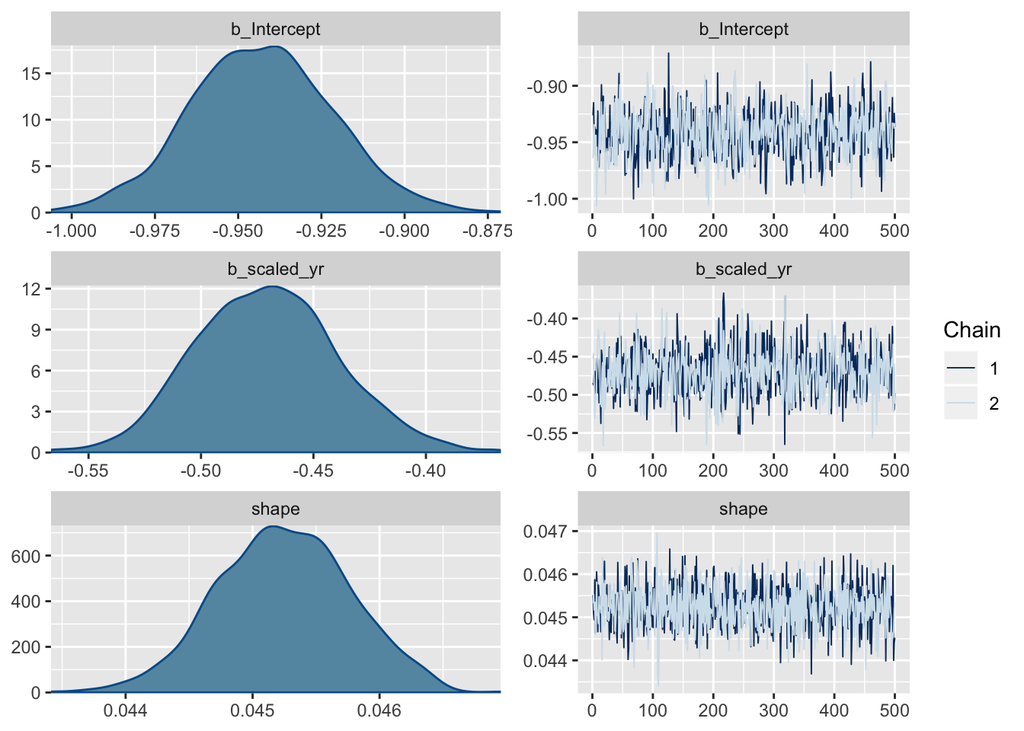

```r
plot(brm_no_ants)
```

```r
fixef(brm_no_ants)[1:2, ] %>%
  exp()
```

```
##            Estimate Est.Error      Q2.5     Q97.5
## Intercept 0.3894307  1.021603 0.3730439 0.4065360
## scaled_yr 0.6246241  1.032186 0.5897542 0.6669078
```

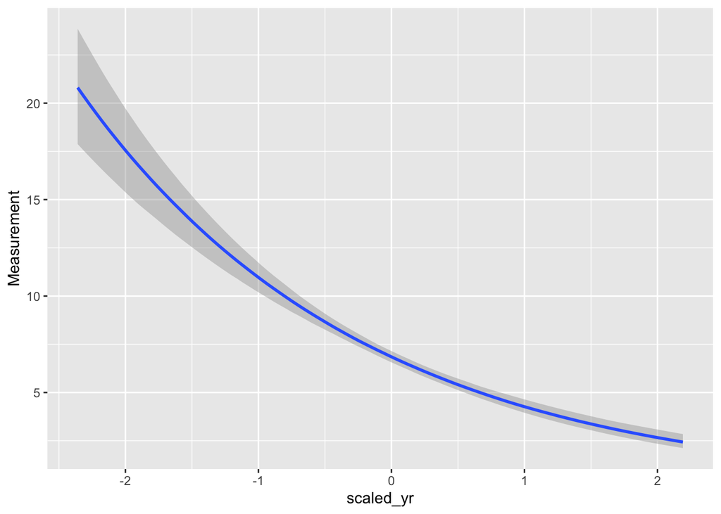

```r
plot(marginal_effects(brm_no_ants))
```

```r
pp_check(brm_no_ants)
```

```
## Using 10 posterior samples for ppc type 'dens_overlay' by default.
```

[figure not shown]

Another idea that Glauco gave me was to use only invertebrate abundances from forest biomes and avoid the grasslands and savannas. So here is the analysis using a subset excluding open biomes. I will also keep the ants out of this analysis.

```r
dat_no_grassland <- dat_no_ants %>%
        filter(Biome %in% c("Mangroves", "Mediterranean Forests, Woodlands & Scrub","Temperate Broadleaf & Mixed Forests","Tropical & Subtropical Dry Broadleaf Forests","Tropical & Subtropical Moist Broadleaf Forests")
               )

save(dat_no_grassland, file = "dat_no_grassland.rds")
```

## Arthropod abundance model without ants and excluding open biomes

Model with no ant abundance and excluding grasslands/open biomes:

```r
start_time <- Sys.time()
brm_no_ants_no_grass <-
  brm(data = dat_no_grassland, family = negbinomial,
      Measurement ~ 1 + offset(log_sampling) + scaled_yr,
      prior = c(prior(normal(0, 10), class = Intercept),
                prior(normal(0, 1), class = b),
                prior(gamma(0.01, 0.01), class = shape) # the brms default
                ),
      cores = 2,
      chains = 2,
      iter = 1000)
end_time <- Sys.time();end_time - start_time
```

```
## Time difference of 3.451267 mins
```

```r
save(brm_no_ants_no_grass, file = "brm_no_ants_no_grass.rda")
```

Loading arthropod abundance model (without ants and no grasslands) to check summary and convergence.

```r
load("brm_no_ants_no_grass.rda")

summary(brm_no_ants_no_grass)
```

```
##  Family: negbinomial
##   Links: mu = log; shape = identity
## Formula: Measurement ~ 1 + offset(log_sampling) + scaled_yr
##    Data: dat_no_grassland (Number of observations: 45079)
## Samples: 2 chains, each with iter = 1000; warmup = 500; thin = 1;
##          total post-warmup samples = 1000
##
## Population-Level Effects:
##           Estimate Est.Error l-95% CI u-95% CI Eff.Sample Rhat
## Intercept    -0.97      0.02    -1.01    -0.93        995 1.00
## scaled_yr    -0.49      0.03    -0.55    -0.43        862 1.00
##
## Family Specific Parameters:
##       Estimate Est.Error l-95% CI u-95% CI Eff.Sample Rhat
## shape     0.05      0.00     0.04     0.05       1102 1.00
##
## Samples were drawn using sampling(NUTS). For each parameter, Eff.Sample
## is a crude measure of effective sample size, and Rhat is the potential
## scale reduction factor on split chains (at convergence, Rhat = 1).
```

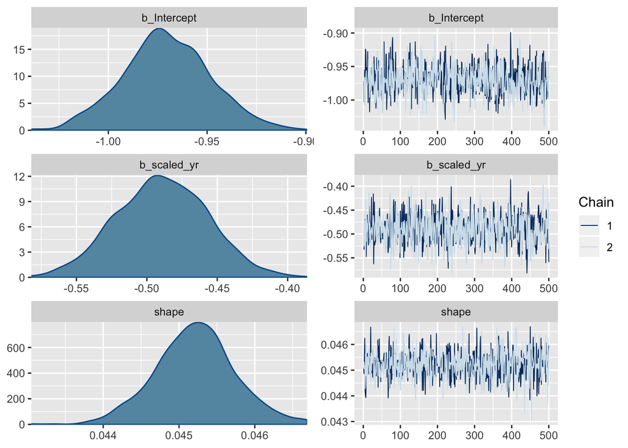

```r
plot(brm_no_ants_no_grass)
```

```r
fixef(brm_no_ants_no_grass)[1:2, ] %>%
  exp()
```

```
##            Estimate Est.Error      Q2.5     Q97.5
## Intercept 0.3789521  1.022310 0.3630383 0.3960838
## scaled_yr 0.6131211  1.032597 0.5752041 0.6516659
```

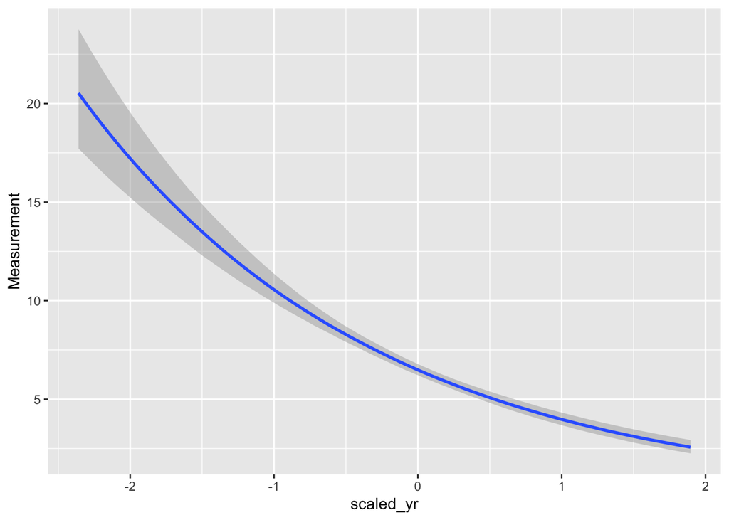

```r
plot(marginal_effects(brm_no_ants_no_grass))
```

```r
pp_check(brm_no_ants_no_grass)
```

```
## Using 10 posterior samples for ppc type 'dens_overlay' by default.
```

[figure not shown]

> One idea I had today (Jun/24) was to use the predicted abundance of arthropods per year as a predictor in the wing length model to investigate whether bird body size is tracking temperature per se or food availability.

# References

Gardner, Janet L., Anne Peters, Michael R. Kearney, Leo Joseph, and Robert Heinsohn. 2011. “Declining Body Size: A Third Universal Response to Warming?” *Trends in Ecology & Evolution* 26 (6): 285–91. doi:10.1016/j.tree.2011.03.005.

Hudson, Lawrence N, Tim Newbold, Sara Contu, Samantha LL Hill, Igor Lysenko, Adriana De Palma, Helen RP Phillips, et al. 2017. “The Database of the Predicts (Projecting Responses of Ecological Diversity in Changing Terrestrial Systems) Project.” *Ecology and Evolution* 7 (1). Wiley Online Library: 145–88.

Jetz, W, GH Thomas, JB Joy, K Hartmann, and AO Mooers. 2012. “The Global Diversity of Birds in Space and Time.” *Nature* 491 (7424). Nature Publishing Group: 444.

Ozgul, Arpat, Shripad Tuljapurkar, Tim G. Benton, Josephine M. Pemberton, Tim H. Clutton-Brock, and Tim Coulson. 2009. “The Dynamics of Phenotypic Change and the Shrinking Sheep of St. Kilda.” *Science* 325 (5939): 464–67. doi:10.1126/science.1173668.

Parmesan, Camille, and Gary Yohe. 2003. “A Globally Coherent Fingerprint of Climate Change Impacts Across Natural Systems.” *Nature* 421 (6918): 37. doi:10.1038/nature01286.

Rode, Karyn D., Steven C. Amstrup, and Eric V. Regehr. 2010. “Reduced Body Size and Cub Recruitment in Polar Bears Associated with Sea Ice Decline.” *Ecological Applications* 20 (3): 768–82. doi:10.1890/08-1036.1.

Rodrigues, Rodolpho Credo, Érica Hasui, Julia Camara Assis, João Carlos Castro Pena, Renata L. Muylaert, Vinicius Rodrigues Tonetti, Felipe Martello, et al. 2019. “ATLANTIC BIRD TRAITS: A Data Set of Bird Morphological Traits from the Atlantic Forests of South America.” *Ecology* 100 (6): e02647. doi:10.1002/ecy.2647.

Schmidt, Niels, and Per Jensen. 2005. “Concomitant Patterns in Avian and Mammalian Body Length Changes in Denmark.” *Ecology and Society* 10 (2). doi:10/gf389w.

Sheridan, Jennifer A., and David Bickford. 2011. “Shrinking Body Size as an Ecological Response to Climate Change.” *Nature Climate Change* 1 (8): 401–6. doi:10.1038/nclimate1259.

Teplitsky, Celine, and Virginie Millien. 2014. “Climate Warming and Bergmann’s Rule Through Time: Is There Any Evidence?” *Evolutionary Applications* 7 (1): 156–68. doi:10.1111/eva.12129.

Teplitsky, Céline, James A. Mills, Jussi S. Alho, John W. Yarrall, and Juha Merilä. 2008. “Bergmann’s Rule and Climate Change Revisited: Disentangling Environmental and Genetic Responses in a Wild Bird Population.” *Proceedings of the National Academy of Sciences* 105 (36): 13492–6. doi:10.1073/pnas.0800999105.

Wilman, Hamish, Jonathan Belmaker, Jennifer Simpson, Carolina de la Rosa, Marcelo M Rivadeneira, and Walter Jetz. 2014. “EltonTraits 1.0: Species-Level Foraging Attributes of the World’s Birds and Mammals: Ecological Archives E095-178.” *Ecology* 95 (7). Wiley Online Library: 2027–7.

[^1]: The paper should then start with an introductory paragraph (not abstract) of no more than 200 words, summarizing the background, rationale, main results (introduced by ‘Here we show’ or some equivalent phrase) and implications of the study. This paragraph should be fully referenced. Check other guidelines to **Nature Climate Change** here: https://www.nature.com/nclimate/about/content
[^2]: I think that this paragraph is not necessary. Talk only about the ecological consequences.
[^3]: We need to choose what precipitation variable to use. It would be good to choose one that relates to the availability of food (insects or fruits).
[^4]: These plots are just for exploratory purposes. I can hide them later when writing the manuscript
[^5]: Glauco’s comments on July 04 2019: 1. Uni ou biparental??? 2. What is the physiological response of birds to an increase in air temperature? Should they react by reducing body size in order to dissipate heat better. 3. Estimate the heritability of wing length. Look up the average generation time for passerine birds. Estimate what is the selection differential on wing length over the period of the data. 4. I thought later about migratory status of the birds. Should I include it in the analysis?
[^6]: https://bookdown.org/ajkurz/Statistical_Rethinking_recoded/missing-data-and-other-opportunities.html